# ppsynth: partial pooling for synthetic control with multiple outcomes

`ppsynth` implements the estimator in Grier (2026), “Correlated Weights: Partial Pooling for Synthetic Control with Multiple Outcomes”. It is the R counterpart of the Stata command `ppsynth`, with the same options, the same returned quantities and the same printed display, and its engines are certified against the Python engine the Stata command calls.

A study that applies the synthetic control method to several outcomes faces a choice: fit each outcome its own donor weights, or impose one common set on all of them. `ppsynth()` makes the middle available. Each outcome gets its own weights, their dispersion around a common centroid is penalized, no single penalty is ever selected (the estimator aggregates over a grid by leave-one-out exponential weighting), and the resulting mass profile reports how much pooling the data support.

## The worked example: German reunification

The package ships the panel of Section 5A of the paper: five outcomes for 21 OECD countries, 1970-2004, Germany (`id = 8`) treated from 1990.

```r
library(ppsynth)
data(germany_panel)
outs <- c("proprights", "money", "inttrade", "regulation", "csh_g")

fit <- ppsynth(germany_panel, outcomes = outs,
               id = "id", time = "year", trunit = 8, trperiod = 1990)
fit
```

```
#>
#> Partial-pooling synthetic control (5 outcomes, method = aggregate)
#> ----------------------------------------------------------------
#>   pre: 20   post: 15   donors: 20
#> ----------------------------------------------------------------
#>    outcome      mean post-treatment effect    pre-RMSPE
#>   proprights                      -0.07577      0.03276
#>     money                         -0.03366       0.1148
#>    inttrade                        0.04376       0.2204
#>   regulation                       -0.1108       0.1834
#>     csh_g                         0.008094     0.002093
#> ----------------------------------------------------------------
#>   Realized weight pooling: 16.1%
#>   Middle 50% of predictive mass: 4% to 24% pooling
#> ----------------------------------------------------------------
#>   (add inference = TRUE for placebo p-values, massprofile = TRUE for the lambda grid)
#>
#>   CAUTION: outcome 'inttrade' lies outside the support of the donor outcomes in 15 of 20 pre-treatment periods (75%). Synthetic control weights cannot extrapolate beyond the donor range. Check the data and consider revising the donor pool before proceeding.
```

This mirrors the Stata call

```
ppsynth proprights money inttrade regulation csh_g, trunit(8) trperiod(1990) id(id) time(year)
```

and prints the same display: the per-outcome mean post-treatment effects and pre-RMSPE, then the realized weight pooling of the final estimator and the middle 50% of predictive mass on the pooling scale. The lambda-grid mass profile (the Stata `massprofile` option) is one argument away:

```r
print(fit, massprofile = TRUE)
```

```
#>
#> Partial-pooling synthetic control (5 outcomes, method = aggregate)
#> ----------------------------------------------------------------
#>   pre: 20   post: 15   donors: 20
#> ----------------------------------------------------------------
#>    outcome      mean post-treatment effect    pre-RMSPE
#>   proprights                      -0.07577      0.03276
#>     money                         -0.03366       0.1148
#>    inttrade                        0.04376       0.2204
#>   regulation                       -0.1108       0.1834
#>     csh_g                         0.008094     0.002093
#> ----------------------------------------------------------------
#>   Realized weight pooling: 16.1%
#>   Middle 50% of predictive mass: 4% to 24% pooling
#> ----------------------------------------------------------------
#>   (add inference = TRUE for placebo p-values)
#>
#>   Aggregation mass profile:
#>     lambda     0  0.01  0.03   0.1   0.3     1     3    10    30   inf
#>     pool %     0     1     4     8    12    24    37    50    69   100
#>     mass %  11.9  12.6  12.9  14.0  15.7  16.3  13.3   3.3   0.1   0.0
#>     Note: pooling per lambda is panel-specific; see ?ppsynth.
#>
#>   CAUTION: outcome 'inttrade' lies outside the support of the donor outcomes in 15 of 20 pre-treatment periods (75%). Synthetic control weights cannot extrapolate beyond the donor range. Check the data and consider revising the donor pool before proceeding.
```

The mass profile is an interior hump: the data reject common weights but do not endorse fully separate fits either. The per-outcome donor weights (Stata’s `r(gamma)`) and the effects:

```r
round(fit$gamma, 2)
```

```
#>    proprights money inttrade regulation csh_g
#> 1        0.34  0.00      0.0       0.00  0.03
#> 2        0.00  0.23      0.0       0.09  0.03
#> 3        0.00  0.01      0.0       0.02  0.00
#> 4        0.00  0.00      0.0       0.00  0.00
#> 5        0.00  0.00      0.0       0.00  0.16
#> 6        0.00  0.00      0.0       0.00  0.00
#> 7        0.00  0.00      0.0       0.09  0.04
#> 9        0.00  0.00      0.0       0.00  0.00
#> 10       0.26  0.00      0.0       0.00  0.15
#> 11       0.00  0.00      0.0       0.13  0.02
#> 12       0.00  0.03      0.0       0.13  0.01
#> 13       0.00  0.27      0.0       0.01  0.01
#> 14       0.00  0.00      0.0       0.00  0.00
#> 15       0.00  0.05      0.0       0.00  0.03
#> 16       0.00  0.00      0.0       0.21  0.01
#> 17       0.00  0.00      0.0       0.08  0.00
#> 18       0.25  0.00      0.0       0.04  0.05
#> 19       0.00  0.34      0.1       0.00  0.18
#> 20       0.00  0.00      0.0       0.00  0.13
#> 21       0.15  0.07      0.9       0.18  0.16
```

```r
fit$tau
```

```
#>   proprights        money     inttrade   regulation        csh_g
#> -0.075772935 -0.033663742  0.043760226 -0.110776553  0.008093527
```

## Graphs

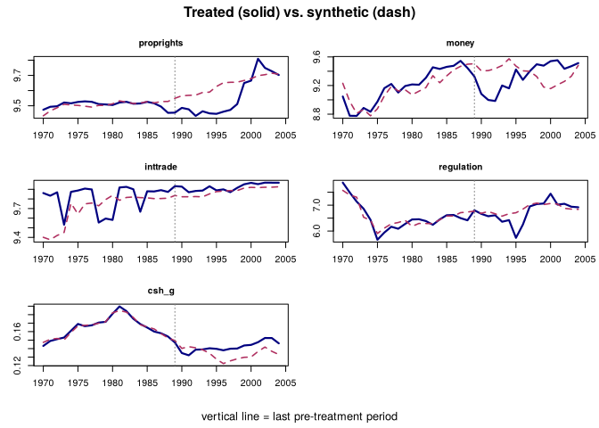

```r
plot(fit, which = "paths")   # treated (solid) vs synthetic (dash), one panel per outcome
```

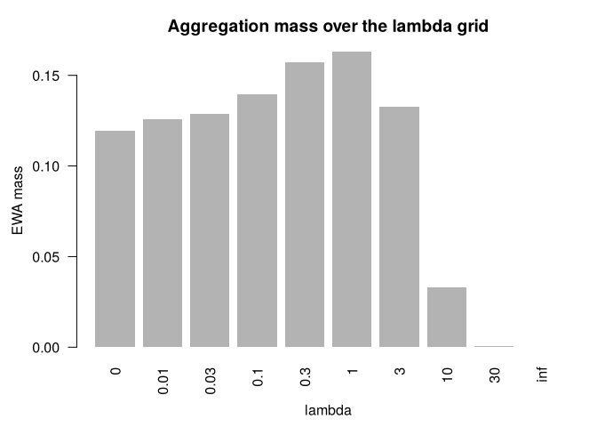

```r
plot(fit, which = "mass")    # aggregation mass over the lambda grid
```

## Placebo inference

`inference = TRUE` reruns the entire pipeline, aggregation included, for each donor treated as a placebo, and reports per-outcome and joint p-values under the Phipson-Smyth convention by default (`convention = "strict"` or `likesynth = TRUE` give the synth-style strict count). On this panel the 21 re-estimations take a minute or two on one core; `cores` spreads them across cores without changing any number.

```r
inf <- ppsynth(germany_panel, outcomes = outs,
               id = "id", time = "year", trunit = 8, trperiod = 1990,
               inference = TRUE, cores = 2)
print(inf, effects = TRUE)
plot(inf, which = "gaps")
```

## Matrix interface

`fit_ppsynth()` and `placebo_inference()` take the data as lists of matrices, exactly like the Python functions of the same name, and return the same fields.

```r
Y_tr <- lapply(outs, function(v) germany_panel[[v]][germany_panel$id == 8])
Y_dn <- lapply(outs, function(v)
  sapply(setdiff(sort(unique(germany_panel$id)), 8),
         function(u) germany_panel[[v]][germany_panel$id == u]))
eng <- fit_ppsynth(Y_tr, Y_dn, T0 = 20)
round(eng$agg_mass, 3)
```

```
#>  [1] 0.119 0.126 0.129 0.140 0.157 0.163 0.133 0.033 0.001 0.000
```

## Engines and certification

Two engines run the same algorithm with the same solver settings: `engine = "cpp"` (the default) is a compiled inner solver mirroring the numba engine behind the Stata command, and `engine = "r"` is a pure-R reference solver. Every returned quantity of both engines is compared against the Python engines’ output on the package’s fixtures (`inst/certification/fixtures`, generated by `tools/make_fixtures.py`); the measured deviations are recorded in `inst/certification/results` and the package tests enforce them.